# Travel Package Purchase Prediction

## Background and Contex

You are a Data Scientist for a tourism company named "Visit with us". The Policy Maker of the company wants to enable and establish a viable business model to expand the customer base.

A viable business model is a central concept that helps you to understand the existing ways of doing the business and how to change the ways for the benefit of the tourism sector.

One of the ways to expand the customer base is to introduce a new offering of packages.

Currently, there are 5 types of packages the company is offering - Basic, Standard, Deluxe, Super Deluxe, King. Looking at the data of the last year, we observed that 18% of the customers purchased the packages.

However, the marketing cost was quite high because customers were contacted at random without looking at the available information.

The company is now planning to launch a new product i.e. Wellness Tourism Package. Wellness Tourism is defined as Travel that allows the traveler to maintain, enhance or kick-start a healthy lifestyle, and support or increase one's sense of well-being.

However, this time company wants to harness the available data of existing and potential customers to make the marketing expenditure more efficient.

You as a Data Scientist at "Visit with us" travel company have to analyze the customers' data and information to provide recommendations to the Policy Maker and Marketing Team and also build a model to predict the potential customer who is going to purchase the newly introduced travel package.

## Objective

To predict which customer is more likely to purchase the newly introduced travel package.

## Customer details:

1. CustomerID: Unique customer ID
2. ProdTaken: Whether the customer has purchased a package or not (0: No, 1: Yes)
3. Age: Age of customer
4. TypeofContact: How customer was contacted (Company Invited or Self Inquiry)
5. CityTier: City tier depends on the development of a city, population, facilities, and living standards the categories are ordered i.e. Tier 1 > Tier 2 > Tier 3
6. Occupation: Occupation of customer
7. Gender: Gender of customer
8. NumberOfPersonVisiting: Total number of persons planning to take the trip with the customer
9. PreferredPropertyStar: Preferred hotel property rating by customer
10. MaritalStatus: Marital status of customer
11. NumberOfTrips: Average number of trips in a year by customer
12. Passport: The customer has a passport or not (0: No, 1: Yes)
13. OwnCar: Whether the customers own a car or not (0: No, 1: Yes)
14. NumberOfChildrenVisiting: Total number of children with age less than 5 planning to take the trip with the customer
15. Designation: Designation of the customer in the current organization
16. MonthlyIncome: Gross monthly income of the customer

## Customer interaction data:

1. PitchSatisfactionScore: Sales pitch satisfaction score
2. ProductPitched: Product pitched by the salesperson
3. NumberOfFollowups: Total number of follow-ups has been done by the salesperson after the sales pitch
4. DurationOfPitch: Duration of the pitch by a salesperson to the customer

## Concepts to Cover

1. Overview of the data
2. Data Visualization
3. Data Preparation
4. Choose Model, Train and Evaluate
5. Conclusion
6. Add-on: Statsmodels

## Import Libraries

```python
conda install -c conda-forge xgboost
```

```
Solving environment: done

# All requested packages already installed.
```

```python
# Library to suppress warnings or deprecation notes
import warnings
warnings.filterwarnings('ignore')

# Libraries to help with reading and manipulating data
import numpy as np
import pandas as pd

# Libraries to help with data visualization
import matplotlib.pyplot as plt
%matplotlib inline
import seaborn as sns

# Libraries to split data, impute missing values
from sklearn.model_selection import train_test_split
from sklearn.impute import SimpleImputer

# Libraries to import decision tree classifier and different ensemble classifiers
from sklearn.ensemble import BaggingClassifier
from sklearn.ensemble import RandomForestClassifier
from sklearn.ensemble import AdaBoostClassifier, GradientBoostingClassifier
from sklearn.ensemble import StackingClassifier
from sklearn.tree import DecisionTreeClassifier

# Libtune to tune model, get different metric scores
from sklearn import metrics
from sklearn.metrics import confusion_matrix, classification_report, accuracy_score, precision_score, recall_score, f1_score
from sklearn.model_selection import GridSearchCV
from xgboost import XGBClassifier
from sklearn.metrics import accuracy_score,precision_score,recall_score,f1_score
```

```python
from xgboost import XGBClassifier
```

## Load and explore the data

## Loading Dataset

```python
df = pd.read_csv("Tourism-Table1.csv")
```

```python
data2 = df.copy()
```

```python
df.head(10)
```

|  | CustomerID | ProdTaken | Age | TypeofContact | CityTier | DurationOfPitch | Occupation | Gender | NumberOfPersonVisiting | NumberOfFollowups | ProductPitched | PreferredPropertyStar | MaritalStatus | NumberOfTrips | Passport | PitchSatisfactionScore | OwnCar | NumberOfChildrenVisiting | Designation | MonthlyIncome |
| --- | --- | --- | --- | --- | --- | --- | --- | --- | --- | --- | --- | --- | --- | --- | --- | --- | --- | --- | --- | --- |
| 0 | 200000 | 1 | 41.0 | Self Enquiry | 3 | 6.0 | Salaried | Female | 3 | 3.0 | Deluxe | 3.0 | Single | 1.0 | 1 | 2 | 1 | 0.0 | Manager | 20993.0 |
| 1 | 200001 | 0 | 49.0 | Company Invited | 1 | 14.0 | Salaried | Male | 3 | 4.0 | Deluxe | 4.0 | Divorced | 2.0 | 0 | 3 | 1 | 2.0 | Manager | 20130.0 |
| 2 | 200002 | 1 | 37.0 | Self Enquiry | 1 | 8.0 | Free Lancer | Male | 3 | 4.0 | Basic | 3.0 | Single | 7.0 | 1 | 3 | 0 | 0.0 | Executive | 17090.0 |
| 3 | 200003 | 0 | 33.0 | Company Invited | 1 | 9.0 | Salaried | Female | 2 | 3.0 | Basic | 3.0 | Divorced | 2.0 | 1 | 5 | 1 | 1.0 | Executive | 17909.0 |
| 4 | 200004 | 0 | NaN | Self Enquiry | 1 | 8.0 | Small Business | Male | 2 | 3.0 | Basic | 4.0 | Divorced | 1.0 | 0 | 5 | 1 | 0.0 | Executive | 18468.0 |
| 5 | 200005 | 0 | 32.0 | Company Invited | 1 | 8.0 | Salaried | Male | 3 | 3.0 | Basic | 3.0 | Single | 1.0 | 0 | 5 | 1 | 1.0 | Executive | 18068.0 |
| 6 | 200006 | 0 | 59.0 | Self Enquiry | 1 | 9.0 | Small Business | Female | 2 | 2.0 | Basic | 5.0 | Divorced | 5.0 | 1 | 2 | 1 | 1.0 | Executive | 17670.0 |
| 7 | 200007 | 0 | 30.0 | Self Enquiry | 1 | 30.0 | Salaried | Male | 3 | 3.0 | Basic | 3.0 | Married | 2.0 | 0 | 2 | 0 | 1.0 | Executive | 17693.0 |
| 8 | 200008 | 0 | 38.0 | Company Invited | 1 | 29.0 | Salaried | Male | 2 | 4.0 | Standard | 3.0 | Unmarried | 1.0 | 0 | 3 | 0 | 0.0 | Senior Manager | 24526.0 |
| 9 | 200009 | 0 | 36.0 | Self Enquiry | 1 | 33.0 | Small Business | Male | 3 | 3.0 | Deluxe | 3.0 | Divorced | 7.0 | 0 | 3 | 1 | 0.0 | Manager | 20237.0 |

```python
df.info()
```

```
<class 'pandas.core.frame.DataFrame'>
RangeIndex: 4888 entries, 0 to 4887
Data columns (total 20 columns):
 #   Column                    Non-Null Count  Dtype
---  ------                    --------------  -----
 0   CustomerID                4888 non-null   int64
 1   ProdTaken                 4888 non-null   int64
 2   Age                       4662 non-null   float64
 3   TypeofContact             4863 non-null   object
 4   CityTier                  4888 non-null   int64
 5   DurationOfPitch           4637 non-null   float64
 6   Occupation                4888 non-null   object
 7   Gender                    4888 non-null   object
 8   NumberOfPersonVisiting    4888 non-null   int64
 9   NumberOfFollowups         4843 non-null   float64
 10  ProductPitched            4888 non-null   object
 11  PreferredPropertyStar     4862 non-null   float64
 12  MaritalStatus             4888 non-null   object
 13  NumberOfTrips             4748 non-null   float64
 14  Passport                  4888 non-null   int64
 15  PitchSatisfactionScore    4888 non-null   int64
 16  OwnCar                    4888 non-null   int64
 17  NumberOfChildrenVisiting  4822 non-null   float64
 18  Designation               4888 non-null   object
 19  MonthlyIncome             4655 non-null   float64
dtypes: float64(7), int64(7), object(6)
memory usage: 763.9+ KB
```

```python
df.shape
```

```
(4888, 20)
```

## Let us fix missing values

```python
#find out if there are any missing values in the dataset
df.isna().sum()
```

```
CustomerID                    0
ProdTaken                     0
Age                         226
TypeofContact                25
CityTier                      0
DurationOfPitch             251
Occupation                    0
Gender                        0
NumberOfPersonVisiting        0
NumberOfFollowups            45
ProductPitched                0
PreferredPropertyStar        26
MaritalStatus                 0
NumberOfTrips               140
Passport                      0
PitchSatisfactionScore        0
OwnCar                        0
NumberOfChildrenVisiting     66
Designation                   0
MonthlyIncome               233
dtype: int64
```

### Observation

1. 8 variables have missing values

## Treating missing values

```python
for column in df.columns:
    if df[column].dtype != 'object':
        median = df[column].median()
        df[column] = df[column].fillna(median)

df.isnull().sum()
```

```
CustomerID                   0
ProdTaken                    0
Age                          0
TypeofContact               25
CityTier                     0
DurationOfPitch              0
Occupation                   0
Gender                       0
NumberOfPersonVisiting       0
NumberOfFollowups            0
ProductPitched               0
PreferredPropertyStar        0
MaritalStatus                0
NumberOfTrips                0
Passport                     0
PitchSatisfactionScore       0
OwnCar                       0
NumberOfChildrenVisiting     0
Designation                  0
MonthlyIncome                0
dtype: int64
```

### Observation

1. Type Of Contact is an object which could not filled with median
2. No more missing values in the integer variables

```python
# There ia an observation in a categorical column which have missing values so we will drop them
df = df.dropna()
df.isnull().sum()
```

```
CustomerID                  0
ProdTaken                   0
Age                         0
TypeofContact               0
CityTier                    0
DurationOfPitch             0
Occupation                  0
Gender                      0
NumberOfPersonVisiting      0
NumberOfFollowups           0
ProductPitched              0
PreferredPropertyStar       0
MaritalStatus               0
NumberOfTrips               0
Passport                    0
PitchSatisfactionScore      0
OwnCar                      0
NumberOfChildrenVisiting    0
Designation                 0
MonthlyIncome               0
dtype: int64
```

### Observation.

1. No missing values in the dataset

## Check column types

```python
## Converting the data type of categorical features to 'category'
df_cols = ['ProdTaken','CityTier', 'NumberOfPersonVisiting', 'NumberOfFollowups', 'PreferredPropertyStar', 'Passport','PitchSatisfactionScore','OwnCar','NumberOfChildrenVisiting','NumberOfTrips','TypeofContact']
df[df_cols] = df[df_cols].astype('category')
df.info()
```

```
<class 'pandas.core.frame.DataFrame'>
Int64Index: 4863 entries, 0 to 4887
Data columns (total 20 columns):
 #   Column                    Non-Null Count  Dtype
---  ------                    --------------  -----
 0   CustomerID                4863 non-null   int64
 1   ProdTaken                 4863 non-null   category
 2   Age                       4863 non-null   float64
 3   TypeofContact             4863 non-null   category
 4   CityTier                  4863 non-null   category
 5   DurationOfPitch           4863 non-null   float64
 6   Occupation                4863 non-null   object
 7   Gender                    4863 non-null   object
 8   NumberOfPersonVisiting    4863 non-null   category
 9   NumberOfFollowups         4863 non-null   category
 10  ProductPitched            4863 non-null   object
 11  PreferredPropertyStar     4863 non-null   category
 12  MaritalStatus             4863 non-null   object
 13  NumberOfTrips             4863 non-null   category
 14  Passport                  4863 non-null   category
 15  PitchSatisfactionScore    4863 non-null   category
 16  OwnCar                    4863 non-null   category
 17  NumberOfChildrenVisiting  4863 non-null   category
 18  Designation               4863 non-null   object
 19  MonthlyIncome             4863 non-null   float64
dtypes: category(11), float64(3), int64(1), object(5)
memory usage: 433.9+ KB
```

### Observation

1. The necessary variables with categorical features have being converted

## Value Count of the Categorical Variables

```python
for column in df.columns:
    if df[column].dtype == 'object':
        print(column.upper(),': ',df[column].nunique())
        print(df[column].value_counts().sort_values())
    print('*'*20)
```

```
OCCUPATION :  4
Free Lancer          2
Large Business     434
Small Business    2064
Salaried          2363
Name: Occupation, dtype: int64
GENDER :  3
Fe Male     155
Female     1807
Male       2901
Name: Gender, dtype: int64
PRODUCTPITCHED :  5
King             230
Super Deluxe     342
Standard         742
Deluxe          1717
Basic           1832
Name: ProductPitched, dtype: int64
MARITALSTATUS :  4
Unmarried     682
Single        912
Divorced      944
Married      2325
Name: MaritalStatus, dtype: int64
DESIGNATION :  5
VP                 230
AVP                342
Senior Manager     742
Manager           1717
Executive         1832
Name: Designation, dtype: int64
```

```python
for i in df_cols:
    print('Unique values in',i, 'are :')
    print(df[i].value_counts())
    print('*'*50)
```

```
Unique values in ProdTaken are :
0    3946
1     917
Name: ProdTaken, dtype: int64
Unique values in CityTier are :
1    3173
3    1492
2     198
Name: CityTier, dtype: int64
Unique values in NumberOfPersonVisiting are :
3    2394
2    1401
4    1026
1      39
5       3
Name: NumberOfPersonVisiting, dtype: int64
Unique values in NumberOfFollowups are :
4.0    2106
3.0    1456
5.0     764
2.0     229
1.0     172
6.0     136
Name: NumberOfFollowups, dtype: int64
Unique values in PreferredPropertyStar are :
3.0    3000
5.0     951
4.0     912
Name: PreferredPropertyStar, dtype: int64
Unique values in Passport are :
0    3441
1    1422
Name: Passport, dtype: int64
Unique values in PitchSatisfactionScore are :
3    1466
5     967
1     937
4     910
2     583
Name: PitchSatisfactionScore, dtype: int64
```

[output cut: 13 more lines]

```
1.0      614
4.0      475
5.0      456
6.0      321
7.0      216
8.0      105
22.0       1
21.0       1
20.0       1
19.0       1
Name: NumberOfTrips, dtype: int64
Unique values in TypeofContact are :
Self Enquiry       3444
Company Invited    1419
Name: TypeofContact, dtype: int64
```

## To find out if there are any duplicate variables

```python
# Are there any duplicates ?
dups = df.duplicated()
print('Number of duplicate rows = %d' % (dups.sum()))
#df[dups]
```

```
Number of duplicate rows = 0
```

## Lets look at summary of our data

```python
df.describe(include = 'all').T
```

|  | count | unique | top | freq | mean | std | min | 25% | 50% | 75% | max |
| --- | --- | --- | --- | --- | --- | --- | --- | --- | --- | --- | --- |
| CustomerID | 4863 | NaN | NaN | NaN | 202449 | 1411.63 | 200000 | 201230 | 202456 | 203672 | 204887 |
| ProdTaken | 4863 | 2 | 0 | 3946 | NaN | NaN | NaN | NaN | NaN | NaN | NaN |
| Age | 4863 | NaN | NaN | NaN | 37.5856 | 9.10477 | 18 | 31 | 36 | 43 | 61 |
| TypeofContact | 4863 | 2 | Self Enquiry | 3444 | NaN | NaN | NaN | NaN | NaN | NaN | NaN |
| CityTier | 4863 | 3 | 1 | 3173 | NaN | NaN | NaN | NaN | NaN | NaN | NaN |
| DurationOfPitch | 4863 | NaN | NaN | NaN | 15.3751 | 8.33579 | 5 | 9 | 13 | 19 | 127 |
| Occupation | 4863 | 4 | Salaried | 2363 | NaN | NaN | NaN | NaN | NaN | NaN | NaN |
| Gender | 4863 | 3 | Male | 2901 | NaN | NaN | NaN | NaN | NaN | NaN | NaN |
| NumberOfPersonVisiting | 4863 | 5 | 3 | 2394 | NaN | NaN | NaN | NaN | NaN | NaN | NaN |
| NumberOfFollowups | 4863 | 6 | 4 | 2106 | NaN | NaN | NaN | NaN | NaN | NaN | NaN |
| ProductPitched | 4863 | 5 | Basic | 1832 | NaN | NaN | NaN | NaN | NaN | NaN | NaN |
| PreferredPropertyStar | 4863 | 3 | 3 | 3000 | NaN | NaN | NaN | NaN | NaN | NaN | NaN |
| MaritalStatus | 4863 | 4 | Married | 2325 | NaN | NaN | NaN | NaN | NaN | NaN | NaN |
| NumberOfTrips | 4863 | 12 | 2 | 1456 | NaN | NaN | NaN | NaN | NaN | NaN | NaN |
| Passport | 4863 | 2 | 0 | 3441 | NaN | NaN | NaN | NaN | NaN | NaN | NaN |
| PitchSatisfactionScore | 4863 | 5 | 3 | 1466 | NaN | NaN | NaN | NaN | NaN | NaN | NaN |
| OwnCar | 4863 | 2 | 1 | 3018 | NaN | NaN | NaN | NaN | NaN | NaN | NaN |
| NumberOfChildrenVisiting | 4863 | 4 | 1 | 2135 | NaN | NaN | NaN | NaN | NaN | NaN | NaN |
| Designation | 4863 | 5 | Executive | 1832 | NaN | NaN | NaN | NaN | NaN | NaN | NaN |
| MonthlyIncome | 4863 | NaN | NaN | NaN | 23565.4 | 5270.64 | 1000 | 20479 | 22347 | 25447.5 | 98678 |

### Observation

```python
print(df['Gender'].value_counts())
```

```
Male       2901
Female     1807
Fe Male     155
Name: Gender, dtype: int64
```

```python
replace = ['Fe Male']
final_value = df['Gender'].value_counts().idxmax()
def replace_values(x):
    if x in replace:
        return final_value
    else:
        return x
df['Gender'] = df['Gender'].apply(replace_values)
```

```python
print(df['Gender'].value_counts())
```

```
Male      3056
Female    1807
Name: Gender, dtype: int64
```

## Graphical Visualization of the Data

## Univariance Analysis

```python
# While doing uni-variate analysis of numerical variables we want to study their central tendency
# and dispersion.
# Let us write a function that will help us create boxplot and histogram for any input numerical
# variable.
# This function takes the numerical column as the input and returns the boxplots
# and histograms for the variable.
# Let us see if this help us write faster and cleaner code.
def histogram_boxplot(feature, figsize=(15,10), bins = None):
    """ Boxplot and histogram combined
    feature: 1-d feature array
    figsize: size of fig (default (9,8))
    bins: number of bins (default None / auto)
    """
    f2, (ax_box2, ax_hist2) = plt.subplots(nrows = 2, # Number of rows of the subplot grid= 2
                                           sharex = True, # x-axis will be shared among all subplots
                                           gridspec_kw = {"height_ratios": (.25, .75)},
                                           figsize = figsize
                                           ) # creating the 2 subplots
    sns.boxplot(feature, ax=ax_box2, showmeans=True, color='violet') # boxplot will be created and a star will indicate the mean value of the column
    sns.distplot(feature, kde=F, ax=ax_hist2, bins=bins,color = 'orange') if bins else sns.distplot(feature, kde=False, ax=ax_hist2,color='tab:cyan') # For histogram
    ax_hist2.axvline(np.mean(feature), color='purple', linestyle='--') # Add mean to the histogram
    ax_hist2.axvline(np.median(feature), color='black', linestyle='-') # Add median to the histogram
```

```python
# Function to create barplots that indicate percentage for each category.

def perc_on_bar(plot, feature):
    '''
    plot
    feature: categorical feature
    the function won't work if a column is passed in hue parameter
    '''
    total = len(feature) # length of the column
    for p in ax.patches:
        percentage = '{:.1f}%'.format(100 * p.get_height()/total) # percentage of each class of the category
        x = p.get_x() + p.get_width() / 2 - 0.05 # width of the plot
        y = p.get_y() + p.get_height()           # hieght of the plot
        ax.annotate(percentage, (x, y), size = 12) # annotate the percantage
    plt.show() # show the plot
```

## ProdTaken

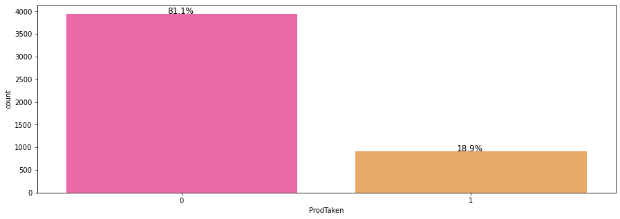

```python
plt.figure(figsize=(15,5))
ax = sns.countplot(df["ProdTaken"],palette='spring')
perc_on_bar(ax,df["ProdTaken"])
```

### Observation.

1. 81% of the customers are not purchasing for the new tourism package.
2. 19% are purchasing the new tourism package

## ProductPitched

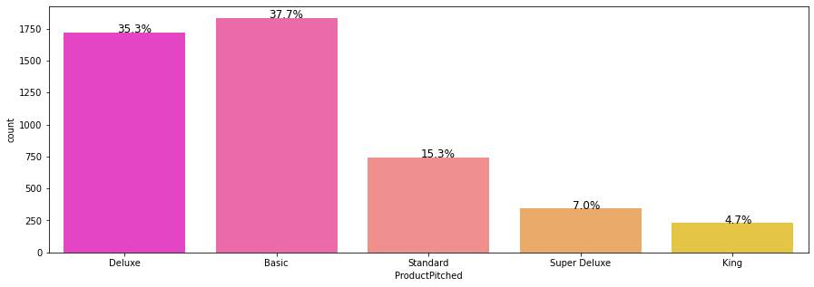

```python
plt.figure(figsize=(15,5))
ax = sns.countplot(df["ProductPitched"],palette='spring')
perc_on_bar(ax,df["ProductPitched"])
```

### Observation.

1. The deluxe and Basic package are the most recommended holiday package by the sales staff.
2. King package is the least selling package by the sales staff.

## TypeofContact

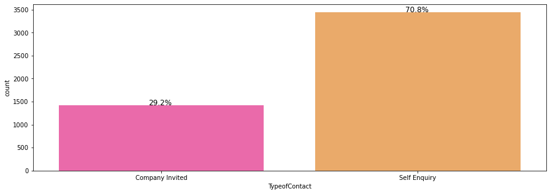

```python
plt.figure(figsize=(15,5))
ax = sns.countplot(df["TypeofContact"],palette='spring')
perc_on_bar(ax,df["TypeofContact"])
```

### Observation.

1. Most customers and holidays are booked through Self Enquire

## Occupation

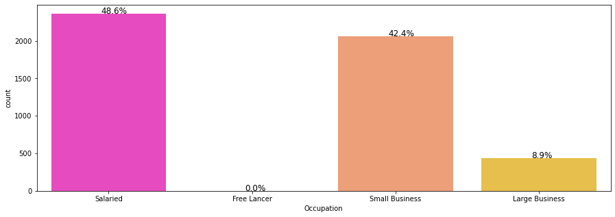

```python
plt.figure(figsize=(15,5))
ax = sns.countplot(df["Occupation"],palette='spring')
perc_on_bar(ax,df["Occupation"])
```

## MaritalStatus

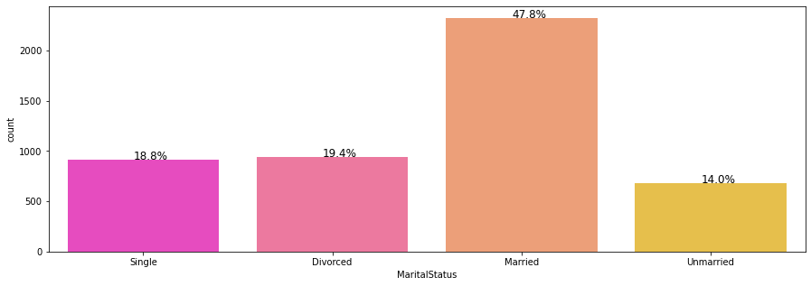

```python
plt.figure(figsize=(15,5))
ax = sns.countplot(df["MaritalStatus"],palette='spring')
perc_on_bar(ax,df["MaritalStatus"])
```

### Observation.

1. Married couples are 48% Visit with us customers

## Designation

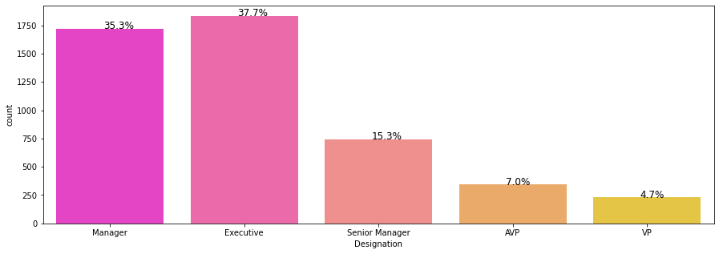

```python
plt.figure(figsize=(15,5))
ax = sns.countplot(df["Designation"],palette='spring')
perc_on_bar(ax,df["Designation"])
```

### Observation

1. Managers and Executives are the highest job designation who book holidays.

## CityTier

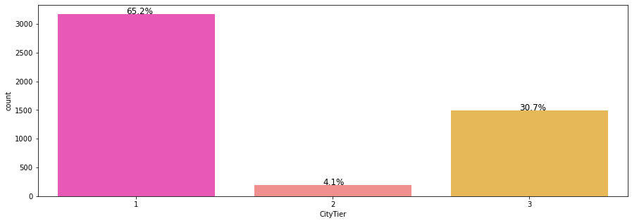

```python
plt.figure(figsize=(15,5))
ax = sns.countplot(df["CityTier"],palette='spring')
perc_on_bar(ax,df["CityTier"])
```

### Observation

1. Tier 1 cities have the highest booking for hoilidays

## NumberOfPersonVisiting

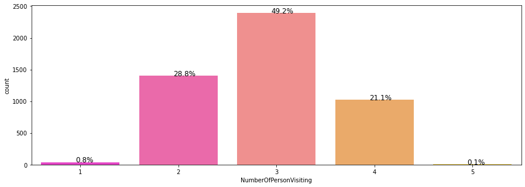

```python
plt.figure(figsize=(15,5))
ax = sns.countplot(df["NumberOfPersonVisiting"],palette='spring')
perc_on_bar(ax,df["NumberOfPersonVisiting"])
```

### Observation

1. A company of 3 book the highest number of hoilidays

## NumberOfFollowups

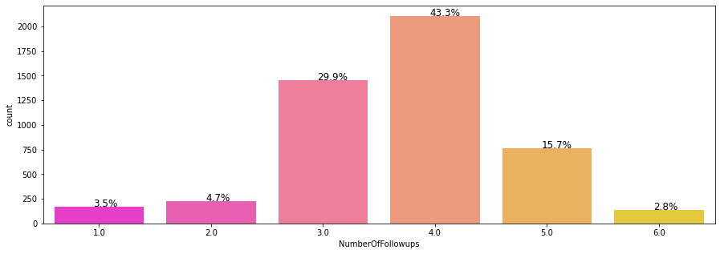

```python
plt.figure(figsize=(15,5))
ax = sns.countplot(df["NumberOfFollowups"],palette='spring')
perc_on_bar(ax,df["NumberOfFollowups"])
```

### Observation

1. the highest Sale personel follow up is 3 & 4 customers follow up

## PreferredPropertyStar

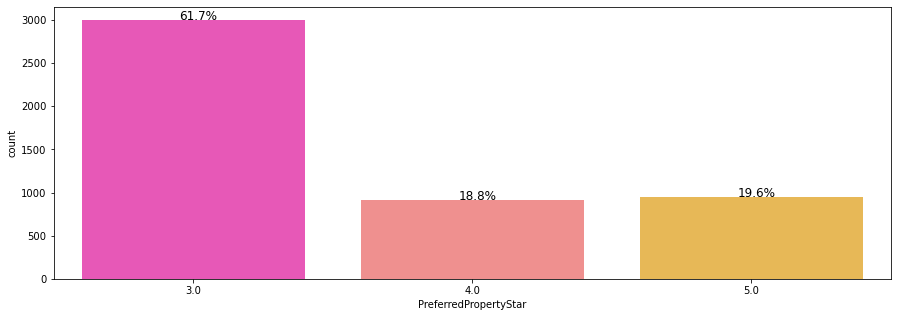

```python
plt.figure(figsize=(15,5))
ax = sns.countplot(df["PreferredPropertyStar"],palette='spring')
perc_on_bar(ax,df["PreferredPropertyStar"])
```

### Observation

1. 62% of the customers prefer 3 star property for holidays.
2. 4 and 5 star property are 19% and 20% respectively

## Gender

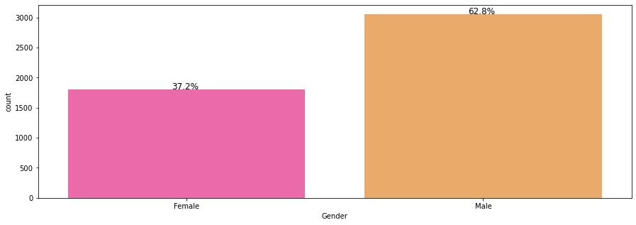

```python
plt.figure(figsize=(15,5))
ax = sns.countplot(df["Gender"],palette='spring')
perc_on_bar(ax,df["Gender"])
```

## Observation

1. 62.8% of the customers are Male

## OwnCar

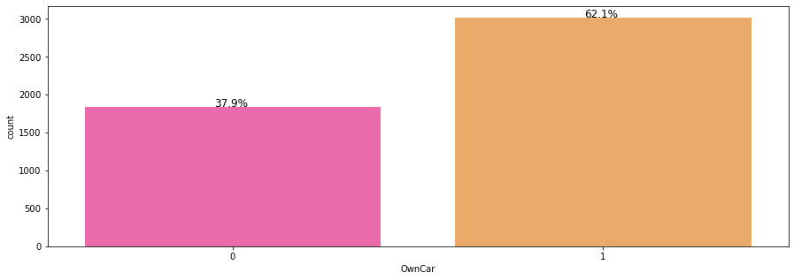

```python
plt.figure(figsize=(15,5))
ax = sns.countplot(df["OwnCar"],palette='spring')
perc_on_bar(ax,df["OwnCar"])
```

## Observation

1. 62.1% of the customers are Own Cars

## Passport

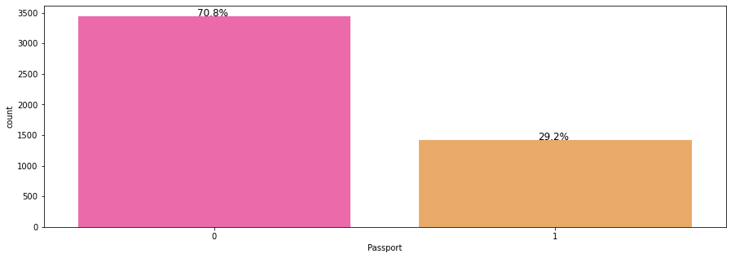

```python
plt.figure(figsize=(15,5))
ax = sns.countplot(df["Passport"],palette='spring')
perc_on_bar(ax,df["Passport"])
```

## Observation

1. A higher percentage of 71% of the organization do not have passport

## PitchSatisfactionScore

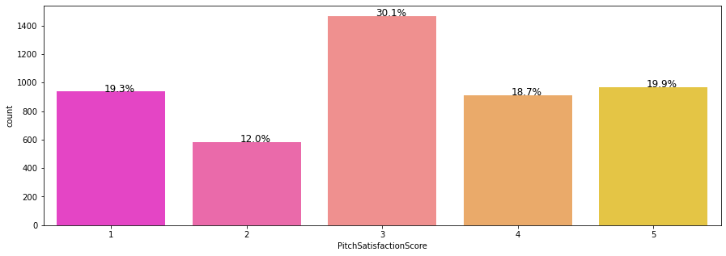

```python
plt.figure(figsize=(15,5))
ax = sns.countplot(df["PitchSatisfactionScore"],palette='spring')
perc_on_bar(ax,df["PitchSatisfactionScore"])
```

### Observation

1. The highest Customers pitch satisfaction score is at a rating of 3
2. Pitch satisfaction score of 1, 4 and 5 are the same the board.

## Age

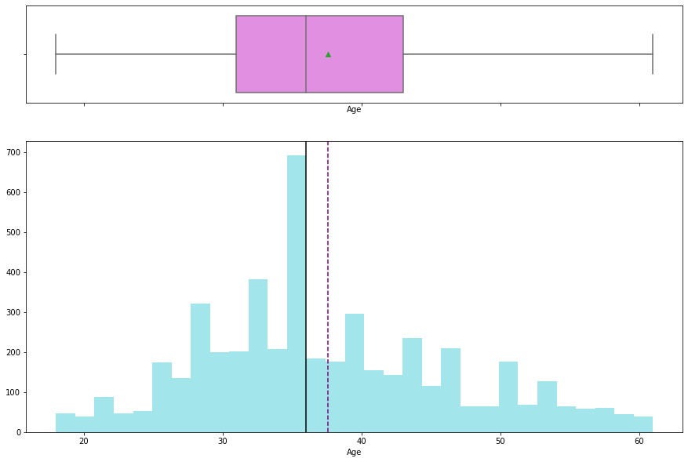

```python
histogram_boxplot(df["Age"])
```

## Observation

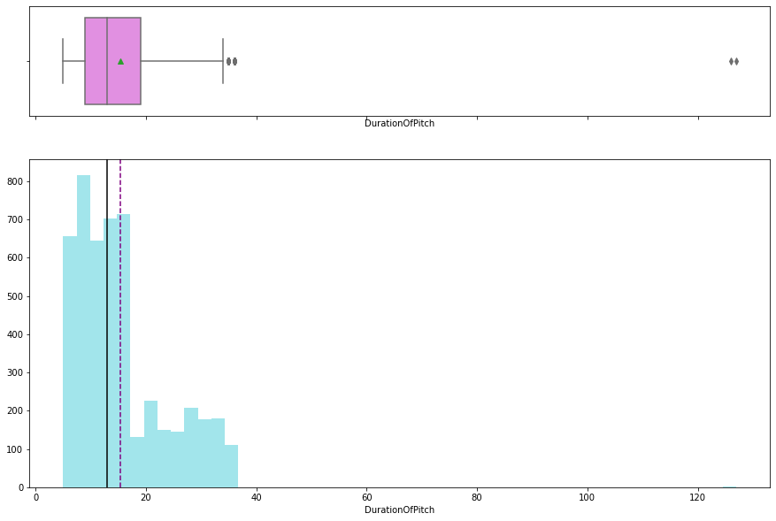

```python
histogram_boxplot(df["DurationOfPitch"])
```

### Observation.

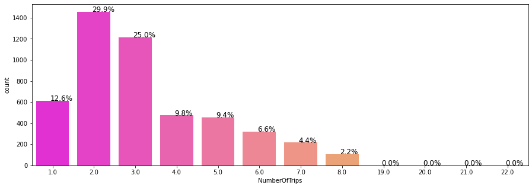

```python
plt.figure(figsize=(15,5))
ax = sns.countplot(df["NumberOfTrips"],palette='spring')
perc_on_bar(ax,df["NumberOfTrips"])
```

### Observation.

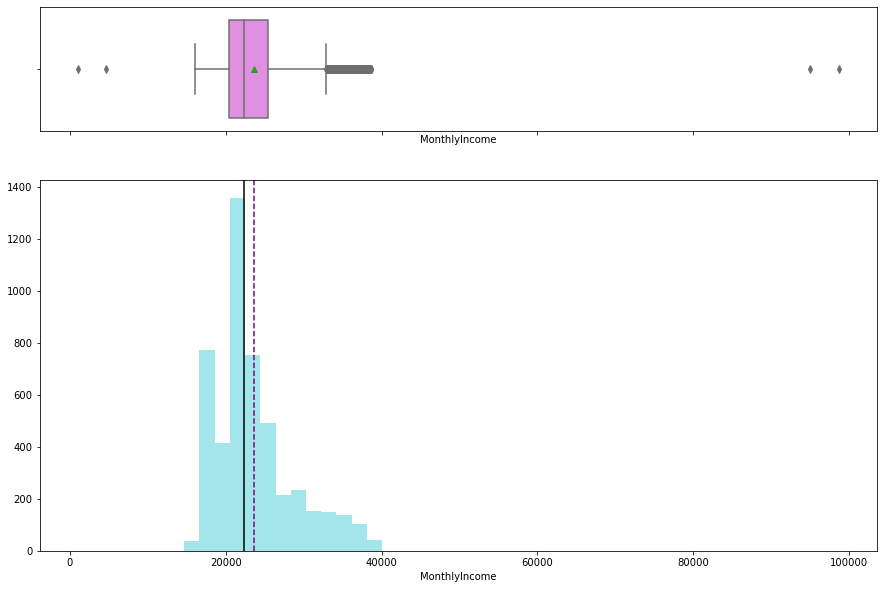

```python
histogram_boxplot(df["MonthlyIncome"])
```

### Observation.

1. Most customers earn an average of 23,000
2. Few customer earn between 90,000-100,000 which are the outliers

## ProdTaken Vs Number of Trips

| ProdTaken NumberOfTrips | 0 | 1 |
| --- | --- | --- |
| 1.0 | 81.758958 | 18.241042 |
| 2.0 | 79.464286 | 20.535714 |
| 3.0 | 81.167763 | 18.832237 |
| 4.0 | 87.368421 | 12.631579 |
| 5.0 | 86.403509 | 13.596491 |
| 6.0 | 80.062305 | 19.937695 |
| 7.0 | 72.222222 | 27.777778 |
| 8.0 | 72.380952 | 27.619048 |
| 19.0 | 0.000000 | 100.000000 |
| 20.0 | 0.000000 | 100.000000 |
| 21.0 | 100.000000 | 0.000000 |
| 22.0 | 100.000000 | 0.000000 |

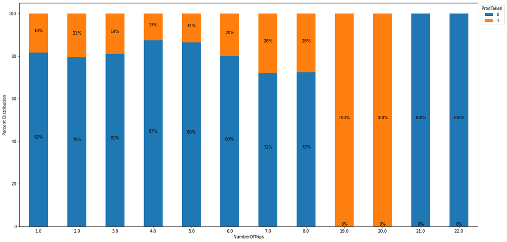

```python
ax= pd.crosstab(df['NumberOfTrips'], df['ProdTaken']).apply(lambda r: r/r.sum()*100, axis=1)
ax_1 = ax.plot.bar(figsize=(20,10),stacked=True, rot=0)
display(ax)

plt.legend(loc='upper left', bbox_to_anchor=(1,1), title="ProdTaken")

plt.xlabel('NumberOfTrips')
plt.ylabel('Percent Distribution')

for rec in ax_1.patches:
    height = rec.get_height()
    ax_1.text(rec.get_x() + rec.get_width() / 2,
              rec.get_y() + height / 2,
              "{:.0f}%".format(height),
              ha='center',
              va='bottom')

plt.show()
```

### Observation

1. Customers who booked the new travel package travelled 7-8 times in a year.
2. Customers who travelled once and twice have a potential of buying the new package

## ProdTaken Vs Monthly Income

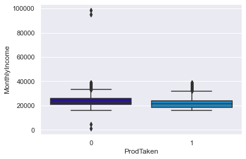

```python
sns.boxplot(x="ProdTaken",y="MonthlyIncome",data=df);
```

### Observation

1. The average Customers who purchase the wellness package earn 21,000 and a maximum od 36,000
2. There are outliers who earn a maximum of 40,000

## ProdTaken Vs Age

| ProdTaken Age | 0 | 1 |
| --- | --- | --- |
| 18.0 | 42.857143 | 57.142857 |
| 19.0 | 34.375000 | 65.625000 |
| 20.0 | 34.210526 | 65.789474 |
| 21.0 | 43.902439 | 56.097561 |
| 22.0 | 67.391304 | 32.608696 |
| 23.0 | 71.739130 | 28.260870 |
| 24.0 | 66.037736 | 33.962264 |
| 25.0 | 73.972603 | 26.027397 |
| 26.0 | 63.725490 | 36.274510 |
| 27.0 | 77.941176 | 22.058824 |
| 28.0 | 83.448276 | 16.551724 |
| 29.0 | 67.613636 | 32.386364 |
| 30.0 | 75.879397 | 24.120603 |
| 31.0 | 79.601990 | 20.398010 |
| 32.0 | 79.487179 | 20.512821 |
| 33.0 | 78.723404 | 21.276596 |
| 34.0 | 78.846154 | 21.153846 |
| 35.0 | 85.654008 | 14.345992 |
| 36.0 | 84.429825 | 15.570175 |
| 37.0 | 87.027027 | 12.972973 |
| 38.0 | 91.477273 | 8.522727 |
| 39.0 | 90.666667 | 9.333333 |
| 40.0 | 84.246575 | 15.753425 |
| 41.0 | 84.415584 | 15.584416 |
| 42.0 | 85.915493 | 14.084507 |
| 43.0 | 92.307692 | 7.692308 |
| 44.0 | 83.809524 | 16.190476 |
| 45.0 | 84.347826 | 15.652174 |
| 46.0 | 90.909091 | 9.090909 |
| 47.0 | 86.363636 | 13.636364 |
| 48.0 | 83.076923 | 16.923077 |
| 49.0 | 86.153846 | 13.846154 |
| 50.0 | 86.046512 | 13.953488 |
| 51.0 | 81.111111 | 18.888889 |
| 52.0 | 79.411765 | 20.588235 |
| 53.0 | 87.878788 | 12.121212 |
| 54.0 | 96.721311 | 3.278689 |
| 55.0 | 89.062500 | 10.937500 |
| 56.0 | 79.310345 | 20.689655 |
| 57.0 | 82.758621 | 17.241379 |
| 58.0 | 64.516129 | 35.483871 |
| 59.0 | 72.727273 | 27.272727 |
| 60.0 | 96.551724 | 3.448276 |
| 61.0 | 100.000000 | 0.000000 |

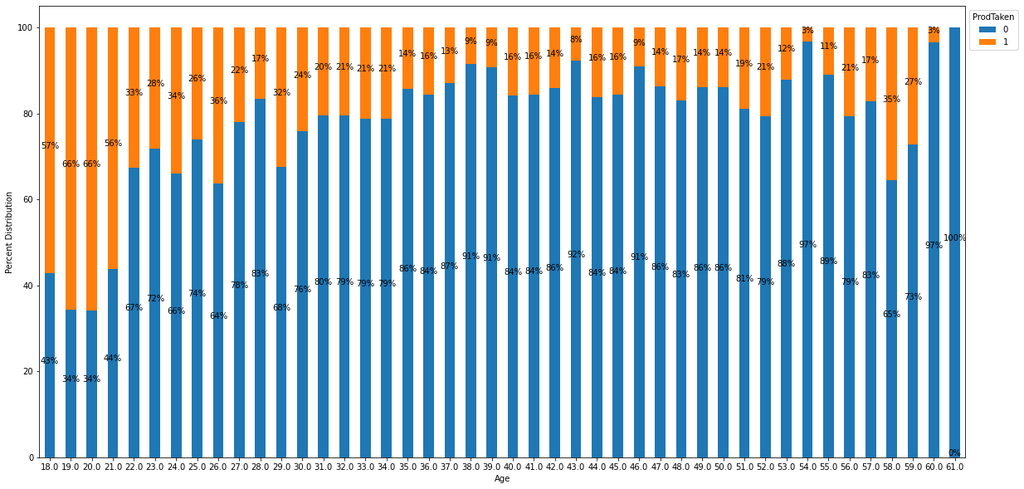

```python
ax= pd.crosstab(df['Age'], df['ProdTaken']).apply(lambda r: r/r.sum()*100, axis=1)
ax_1 = ax.plot.bar(figsize=(20,10),stacked=True, rot=0)
display(ax)

plt.legend(loc='upper left', bbox_to_anchor=(1,1), title="ProdTaken")

plt.xlabel('Age')
plt.ylabel('Percent Distribution')

for rec in ax_1.patches:
    height = rec.get_height()
    ax_1.text(rec.get_x() + rec.get_width() / 2,
              rec.get_y() + height / 2,
              "{:.0f}%".format(height),
              ha='center',
              va='bottom')

plt.show()
```

### Observation

1. The younger demographic are intrested in the new wellness package.
2. The middle age are at an average seem to be keying into the new package.
3. The newly reitrement age of 58-59 years havea good partonage.

## ProdTaken Vs Duration of pitch

| ProdTaken DurationOfPitch | 0 | 1 |
| --- | --- | --- |
| 5.0 | 100.000000 | 0.000000 |
| 6.0 | 87.296417 | 12.703583 |
| 7.0 | 85.964912 | 14.035088 |
| 8.0 | 81.981982 | 18.018018 |
| 9.0 | 83.643892 | 16.356108 |
| 10.0 | 81.557377 | 18.442623 |
| 11.0 | 81.951220 | 18.048780 |
| 12.0 | 83.076923 | 16.923077 |
| 13.0 | 83.518931 | 16.481069 |
| 14.0 | 83.794466 | 16.205534 |
| 15.0 | 80.669145 | 19.330855 |
| 16.0 | 79.562044 | 20.437956 |
| 17.0 | 86.046512 | 13.953488 |
| 18.0 | 74.666667 | 25.333333 |
| 19.0 | 63.157895 | 36.842105 |
| 20.0 | 70.769231 | 29.230769 |
| 21.0 | 78.082192 | 21.917808 |
| 22.0 | 74.157303 | 25.842697 |
| 23.0 | 73.417722 | 26.582278 |
| 24.0 | 77.142857 | 22.857143 |
| 25.0 | 80.821918 | 19.178082 |
| 26.0 | 83.333333 | 16.666667 |
| 27.0 | 80.555556 | 19.444444 |
| 28.0 | 72.131148 | 27.868852 |
| 29.0 | 71.621622 | 28.378378 |
| 30.0 | 68.421053 | 31.578947 |
| 31.0 | 62.650602 | 37.349398 |
| 32.0 | 79.729730 | 20.270270 |
| 33.0 | 80.701754 | 19.298246 |
| 34.0 | 84.000000 | 16.000000 |
| 35.0 | 83.333333 | 16.666667 |
| 36.0 | 77.272727 | 22.727273 |
| 126.0 | 100.000000 | 0.000000 |
| 127.0 | 100.000000 | 0.000000 |

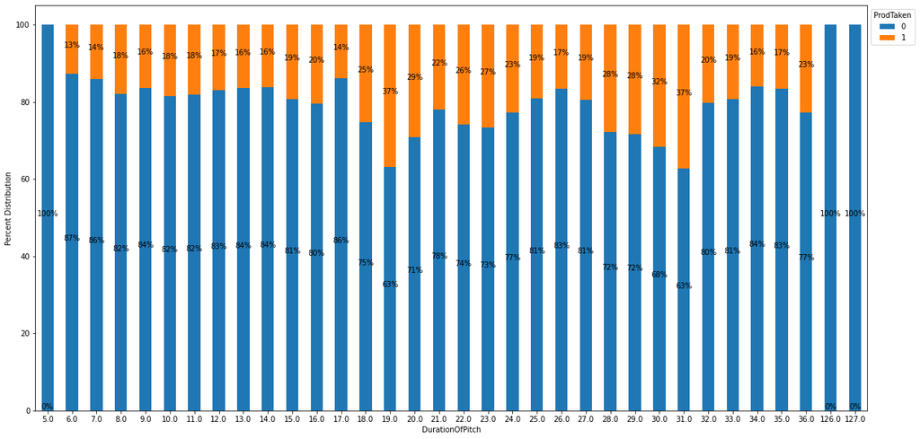

```python
ax= pd.crosstab(df['DurationOfPitch'], df['ProdTaken']).apply(lambda r: r/r.sum()*100, axis=1)
ax_1 = ax.plot.bar(figsize=(20,10),stacked=True, rot=0)
display(ax)

plt.legend(loc='upper left', bbox_to_anchor=(1,1), title="ProdTaken")

plt.xlabel('DurationOfPitch')
plt.ylabel('Percent Distribution')

for rec in ax_1.patches:
    height = rec.get_height()
    ax_1.text(rec.get_x() + rec.get_width() / 2,
              rec.get_y() + height / 2,
              "{:.0f}%".format(height),
              ha='center',
              va='bottom')

plt.show()
```

### Observation

1. The highest number of customers who subscribed to the new travel package took between 20mins to 31mins

```python
### Function to plot stacked bar charts for categorical columns
def stacked_plot(x):
    sns.set(palette='nipy_spectral')
    tab1 = pd.crosstab(x,df['ProdTaken'],margins=True)
    print(tab1)
    print('-'*120)
    tab = pd.crosstab(x,df['ProdTaken'],normalize='index')
    tab.plot(kind='bar',stacked=True,figsize=(10,5))
    plt.legend(loc='lower left', frameon=False)
    plt.legend(loc="upper left", bbox_to_anchor=(1,1))


    plt.show()
```

## ProdTaken Vs Type of Contact

```
ProdTaken           0    1   All
TypeofContact
Company Invited  1109  310  1419
Self Enquiry     2837  607  3444
All              3946  917  4863
------------------------------------------------------------------------------------------------------------------------
```

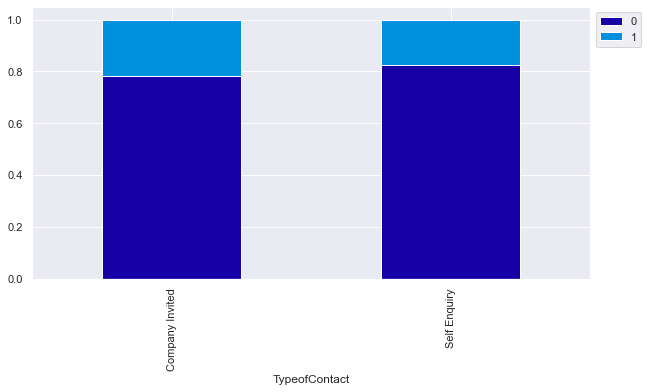

```python
stacked_plot(df['TypeofContact'])
```

## ProdTaken Vs Gender

```
ProdTaken     0    1   All
Gender
Female     1490  317  1807
Male       2456  600  3056
All        3946  917  4863
------------------------------------------------------------------------------------------------------------------------
```

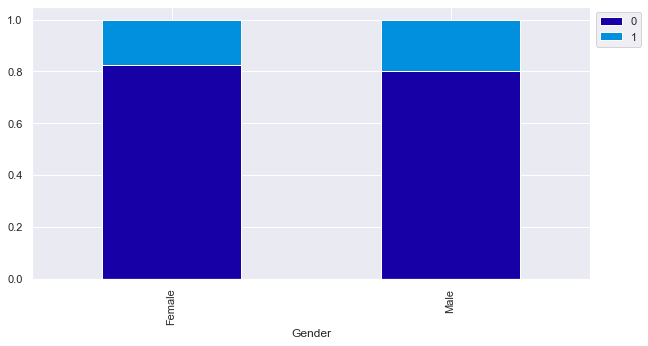

```python
stacked_plot(df['Gender'])
```

### Observation.

1. More male purchased the new travel package than female

## ProdTaken Vs Occupation

```
ProdTaken          0    1   All
Occupation
Free Lancer        0    2     2
Large Business   314  120   434
Salaried        1950  413  2363
Small Business  1682  382  2064
All             3946  917  4863
------------------------------------------------------------------------------------------------------------------------
```

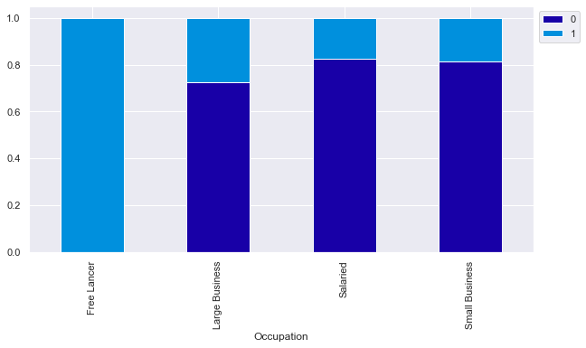

```python
stacked_plot(df['Occupation'])
```

### Observation

1. The 2 Freelance customers purchased the the new wellness package
2. Salaries customers also purchased the new product

## ProdTaken Vs Product pitched

```
ProdTaken          0    1   All
ProductPitched
Basic           1283  549  1832
Deluxe          1513  204  1717
King             210   20   230
Standard         618  124   742
Super Deluxe     322   20   342
All             3946  917  4863
------------------------------------------------------------------------------------------------------------------------
```

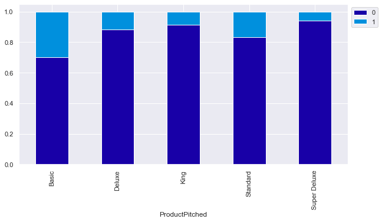

```python
stacked_plot(df['ProductPitched'])
```

### Observation

1. Customers who booked the basic and deluxe product purchased the new wellness product more.
2. Although Basic and Delux package are the highly prurchase products

## ProdTaken Vs Marital Status

```
ProdTaken         0    1   All
MaritalStatus
Divorced        821  123   944
Married        1999  326  2325
Single          610  302   912
Unmarried       516  166   682
All            3946  917  4863
------------------------------------------------------------------------------------------------------------------------
```

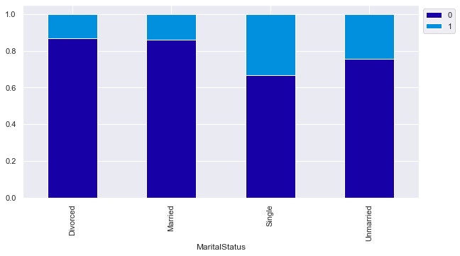

```python
stacked_plot(df['MaritalStatus'])
```

### Observation

1. Married customer go purschased more of the welness package.

## ProdTaken Vs Designation

```
ProdTaken          0    1   All
Designation
AVP              322   20   342
Executive       1283  549  1832
Manager         1513  204  1717
Senior Manager   618  124   742
VP               210   20   230
All             3946  917  4863
------------------------------------------------------------------------------------------------------------------------
```

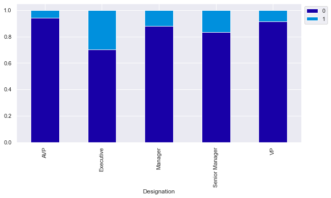

```python
stacked_plot(df['Designation'])
```

## ProdTaken Vs City Tier

```
ProdTaken     0    1   All
CityTier
1          2655  518  3173
2           152   46   198
3          1139  353  1492
All        3946  917  4863
------------------------------------------------------------------------------------------------------------------------
```

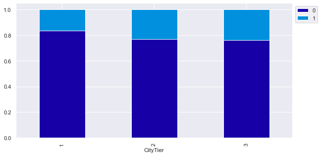

```python
stacked_plot(df['CityTier'])
```

### Observation

1. City tier 1 purchased more of the wellness package.

## ProdTaken Vs Number of Person Visiting

```
ProdTaken                  0    1   All
NumberOfPersonVisiting
1                         39    0    39
2                       1136  265  1401
3                       1935  459  2394
4                        833  193  1026
5                          3    0     3
All                     3946  917  4863
------------------------------------------------------------------------------------------------------------------------
```

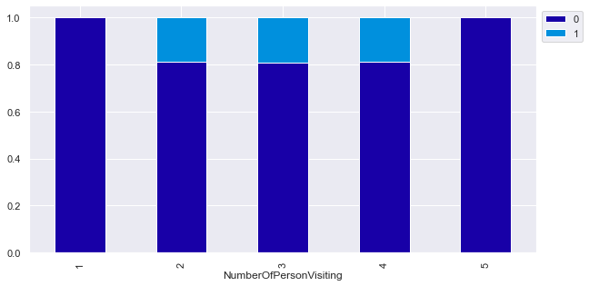

```python
stacked_plot(df['NumberOfPersonVisiting'])
```

### Observation

1. Customers with 1 and 5 companion didn't purchase the welness package
2. Customers with 3 person visit purchased the new package more

## ProdTaken Vs Number of Follow ups

```
ProdTaken             0    1   All
NumberOfFollowups
1.0                 152   20   172
2.0                 205   24   229
3.0                1214  242  1456
4.0                1720  386  2106
5.0                 573  191   764
6.0                  82   54   136
All                3946  917  4863
------------------------------------------------------------------------------------------------------------------------
```

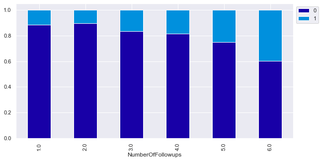

```python
stacked_plot(df['NumberOfFollowups'])
```

### Observation

1. It took the sales personell 3-4 follow ups to convince the highest number of customers who purchased the wellness product